# Ensemble (Machine) Learning with SuperLearner and H2O in R

Nima Hejazi and Evan Muzzall

12/6//2016

# 1. Preliminaries

- In this walkthrough, we will examine how to use the `SuperLearner` R package by looking at the BreastCancer data set from the R package `mlbench`.
- For convenience, the `BreastCancer` dataset is also available in CSV format in the data subdirectory of this repo.

```r
set.seed(654123) # reproducibility matters
"%ni%" = Negate("%in%")

# load some standard packages
library(dplyr)
library(ggplot2)
library(mlbench)

# load the data set
data(BreastCancer)
head(BreastCancer)
```

```
##        Id Cl.thickness Cell.size Cell.shape Marg.adhesion Epith.c.size
## 1 1000025            5         1          1             1            2
## 2 1002945            5         4          4             5            7
## 3 1015425            3         1          1             1            2
## 4 1016277            6         8          8             1            3
## 5 1017023            4         1          1             3            2
## 6 1017122            8        10         10             8            7
##   Bare.nuclei Bl.cromatin Normal.nucleoli Mitoses     Class
## 1           1           3               1       1    benign
## 2          10           3               2       1    benign
## 3           2           3               1       1    benign
## 4           4           3               7       1    benign
## 5           1           3               1       1    benign
## 6          10           9               7       1 malignant
```

# 2. Data Cleaning

- Firstly, we need to transform our data matrix so that it can be easily passed to `SuperLearner`.
- We’ll do this with the `dplyr` package, which we loaded in the above section.

```r
# examine whether there are NAs in the data
colSums(is.na(BreastCancer))
```

```
##              Id    Cl.thickness       Cell.size      Cell.shape
##               0               0               0               0
##   Marg.adhesion    Epith.c.size     Bare.nuclei     Bl.cromatin
##               0               0              16               0
## Normal.nucleoli         Mitoses           Class
##               0               0               0
```

- `SuperLearner` **does not work with missing data**, so we will have to remove incomplete observations.
- There are several ways to handle missing data via imputation with `SuperLearner`, but those are outside the scope of this tutorial. Feel free to ask us after this workshop if you’re interested in this.

```r
# remove the NAs before proceeding with Super Learner
bc <- BreastCancer %>%
 dplyr::filter(complete.cases(.))
colSums(is.na(bc))
```

```
##              Id    Cl.thickness       Cell.size      Cell.shape
##               0               0               0               0
##   Marg.adhesion    Epith.c.size     Bare.nuclei     Bl.cromatin
##               0               0               0               0
## Normal.nucleoli         Mitoses           Class
##               0               0               0
```

- Next, we’ll need to remove the outcome column (“Class”) and the metadata column (“ID”) from the X matrix
- Here, the X matrix is simply the observed values to be used in predicting the class outcome.

```r
# create a data.frame of covariates to be used in prediction
X <- bc %>%
 dplyr::select(which(colnames(.) %ni% c("Id", "Class")))
head(X)
```

```
##   Cl.thickness Cell.size Cell.shape Marg.adhesion Epith.c.size Bare.nuclei
## 1            5         1          1             1            2           1
## 2            5         4          4             5            7          10
## 3            3         1          1             1            2           2
## 4            6         8          8             1            3           4
## 5            4         1          1             3            2           1
## 6            8        10         10             8            7          10
##   Bl.cromatin Normal.nucleoli Mitoses
## 1           3               1       1
## 2           3               2       1
## 3           3               1       1
## 4           3               7       1
## 5           3               1       1
## 6           9               7       1
```

- We simply strip all columns other than the “Class” to create the outcome vector.
- The vector of outcomes must be of class numeric for SuperLearner to work properly.

```r
# create a numeric vector of the binary outcomes.
Y <- bc %>%
 dplyr::select(which(colnames(.) %in% c("Class")))
Y <- as.vector(ifelse(Y == "benign", 0, 1))
unique(Y)
```

```
## [1] 0 1
```

# 3. The Super Learner Algorithm

- **R package:** `SuperLearner`
- Main functions: `SuperLearner`, `CV.SuperLearner`

To start, we will load the `SuperLearner` package and set up a library of learning algorithms that `SuperLearner` will combine into a single ensemble learner.

For the purposes of this walkthrough, we’ll keep the library of learning algorithms limited. Note that in practical cases, the number of learning algorithms should vary with the number of observations, and the bigger your library, the better you will capture the optimal relationship.

```r
library(SuperLearner)
SL_library <- c("SL.gbm", "SL.glm", "SL.glmnet", "SL.knn", "SL.nnet",
                "SL.randomForest")
```

```r
SL_fit <- SuperLearner(X = X,
                       Y = Y,
                       family = binomial(),
                       SL.library = SL_library,
                       verbose = FALSE
                      )
SL_fit$coef
```

```
##          SL.gbm_All          SL.glm_All       SL.glmnet_All
##          0.05804974          0.03057798          0.00000000
##          SL.knn_All         SL.nnet_All SL.randomForest_All
##          0.69153755          0.00000000          0.21983473
```

# 4. The Cross-Validated Super Learner

- “Function to get V-fold cross-validated risk estimate for super learner. This function simply splits the data into V folds and then calls `SuperLearner`.”
- Why would we want to cross-validate the ensembling process used by Super Learner?
- The `SuperLearner` function builds an estimator, but does not contain an estimate of the performance of that estimator.
- The authros recommend using cross-validation to evaluate the honest performance of the super learner estimator.
- The function `CV.SuperLearner` computes the usual V-fold cross-validated risk estimate for the super learner (as well as that for each algorithm in the specified library for comparison).

```r
library(cvAUC)
V = 5 # we'll use few folds here to save time

cv_SL_fit <- CV.SuperLearner(X = X,
                             Y = Y,
                             V = V,
                             family = binomial(),
                             SL.library = SL_library,
                             verbose = FALSE
                            )
cv_SL_fit$coef
```

```
##   SL.gbm_All  SL.glm_All SL.glmnet_All SL.knn_All SL.nnet_All
## 1  0.0000000 0.000000000   0.000000000  0.6579005  0.07731546
## 2  0.1967231 0.000000000   0.004739998  0.1755384  0.03938415
## 3  0.0000000 0.000000000   0.000000000  0.6580631  0.00000000
## 4  0.0000000 0.000000000   0.000000000  0.6719637  0.05121414
## 5  0.3582016 0.006590319   0.000000000  0.5168597  0.00000000
##   SL.randomForest_All
## 1           0.2647841
## 2           0.5836144
## 3           0.3419369
## 4           0.2768221
## 5           0.1183484
```

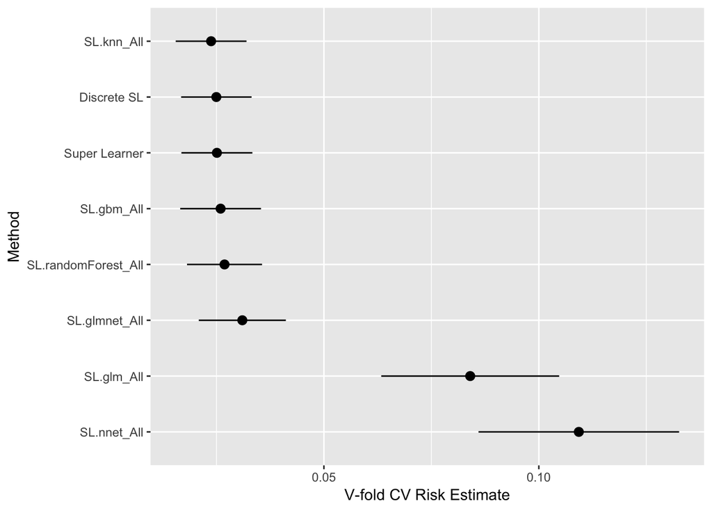

```r
plot(cv_SL_fit)
```

```r
fold = cv_SL_fit$fold
predsY = cv_SL_fit$SL.predict

n = length(predsY)
folds = rep(NA, n)

for(k in 1:V) {
    ii = unlist(fold[k])
    folds[ii] = k
}

ci_out = ci.cvAUC(predsY, Y, folds = folds)
txt = paste("AUC = ", round(ci_out$cvAUC, 2),",
            95% CI = ", round(ci_out$ci[1], 2), "-",
            round(ci_out$ci[2], 2))
```

# 5. Evaluating Classification Results

- The [Receiver Operating Characteristic curve](https://en.wikipedia.org/wiki/Receiver_operating_characteristic) is a standard way of evaluating the results of classification algorithms
- Here, we use the ROCR package to visualize the results from the cross-validated Super Learner

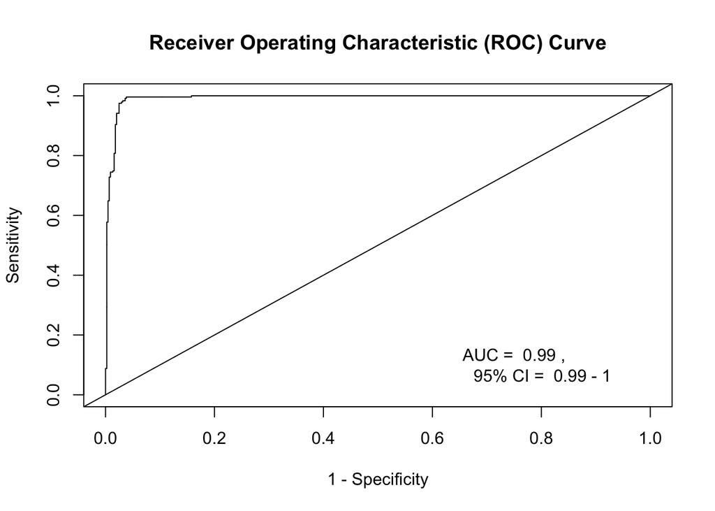

```r
library(ROCR)

pred <- prediction(predsY, Y)
perf <- performance(pred, "sens", "spec")
plot(1 - slot(perf, "x.values")[[1]],
     slot(perf, "y.values")[[1]],
     type = "s",
     xlab = "1 - Specificity",
     ylab = "Sensitivity",
     main = "Receiver Operating Characteristic (ROC) Curve")
text(0.75, 0.1, txt)
abline(0, 1)
```